# Mid Project

2025-11-25

```r
#List of required packages

packages<-c("ggplot2","dplyr","scales","tidyr","GGally","e1071","fastDummies","FSelectorRcpp","corrplot")

# Install any packages that are not already installed
installed_packages<-rownames(installed.packages())
for(pkg in packages){
  if(!(pkg %in% installed_packages)){
    install.packages(pkg)
  }
  library(pkg,character.only=TRUE)
}
```

#A.Data Understanding

```r
#Load dataset
url<-"https://drive.google.com/uc?export=download&id=1IWA5bJ8t7s0pJKCGah4Fg4xVEFWS1SD5"
data<-read.csv(url)
#Show few row of dataset
head(data,10)
```

```
##    Hours_Studied Attendance Parental_Involvement Access_to_Resources
## 1             23         84                  Low                High
## 2             19         64                  Low              Medium
## 3             24         98               Medium              Medium
## 4             29         89                  Low              Medium
## 5             19         92               Medium              Medium
## 6             19         88               Medium              Medium
## 7             29         84               Medium                 Low
## 8             25         78                  Low                High
## 9             17         94               Medium                High
## 10            23         98               Medium              Medium
##    Extracurricular_Activities Sleep_Hours Previous_Scores Motivation_Level
## 1                          No           7              73              Low
## 2                          No           8              59              Low
## 3                         Yes           7              91           Medium
```

[output cut: 40 more lines]

#Show shape of dataset(rowxcolumn)

```r
cat("Row:", nrow(data))
```

```
## Row: 6607
```

```r
cat("Column:", ncol(data))
```

```
## Column: 20
```

#Display data types of each column

```r
str(data)
```

```
## 'data.frame':    6607 obs. of  20 variables:
##  $ Hours_Studied             : int  23 19 24 29 19 19 29 25 17 23 ...
##  $ Attendance                : int  84 64 98 89 92 88 84 78 94 98 ...
##  $ Parental_Involvement      : chr  "Low" "Low" "Medium" "Low" ...
##  $ Access_to_Resources       : chr  "High" "Medium" "Medium" "Medium" ...
##  $ Extracurricular_Activities: chr  "No" "No" "Yes" "Yes" ...
##  $ Sleep_Hours               : int  7 8 7 8 6 8 7 6 6 8 ...
##  $ Previous_Scores           : int  73 59 91 98 65 89 68 50 80 71 ...
##  $ Motivation_Level          : chr  "Low" "Low" "Medium" "Medium" ...
##  $ Internet_Access           : chr  "Yes" "Yes" "Yes" "Yes" ...
##  $ Tutoring_Sessions         : int  0 2 2 1 3 3 1 1 0 0 ...
##  $ Family_Income             : chr  "Low" "Medium" "Medium" "Medium" ...
##  $ Teacher_Quality           : chr  "Medium" "Medium" "Medium" "Medium" ...
##  $ School_Type               : chr  "Public" "Public" "Public" "Public" ...
##  $ Peer_Influence            : chr  "Positive" "Negative" "Neutral" "Negative" ...
##  $ Physical_Activity         : int  3 4 4 4 4 3 2 2 1 5 ...
##  $ Learning_Disabilities     : chr  "No" "No" "No" "No" ...
##  $ Parental_Education_Level  : chr  "High School" "College" "Postgraduate" "High School" ...
##  $ Distance_from_Home        : chr  "Near" "Moderate" "Near" "Moderate" ...
##  $ Gender                    : chr  "Male" "Female" "Male" "Male" ...
##  $ Exam_Score                : int  67 61 74 71 70 71 67 66 69 72 ...
```

#Genrate basic discriptive statistics

```r
summary(data)
```

```
##  Hours_Studied     Attendance     Parental_Involvement Access_to_Resources
##  Min.   : 1.00   Min.   : 60.00   Length:6607          Length:6607
##  1st Qu.:16.00   1st Qu.: 70.00   Class :character     Class :character
##  Median :20.00   Median : 80.00   Mode  :character     Mode  :character
##  Mean   :19.98   Mean   : 79.98
##  3rd Qu.:24.00   3rd Qu.: 90.00
##  Max.   :44.00   Max.   :100.00
##  Extracurricular_Activities  Sleep_Hours     Previous_Scores
##  Length:6607                Min.   : 4.000   Min.   : 50.00
##  Class :character           1st Qu.: 6.000   1st Qu.: 63.00
##  Mode  :character           Median : 7.000   Median : 75.00
##                             Mean   : 7.029   Mean   : 75.07
##                             3rd Qu.: 8.000   3rd Qu.: 88.00
##                             Max.   :10.000   Max.   :100.00
##  Motivation_Level   Internet_Access    Tutoring_Sessions Family_Income
##  Length:6607        Length:6607        Min.   :0.000     Length:6607
##  Class :character   Class :character   1st Qu.:1.000     Class :character
##  Mode  :character   Mode  :character   Median :1.000     Mode  :character
##                                        Mean   :1.494
##                                        3rd Qu.:2.000
##                                        Max.   :8.000
##  Teacher_Quality    School_Type        Peer_Influence     Physical_Activity
##  Length:6607        Length:6607        Length:6607        Min.   :0.000
##  Class :character   Class :character   Class :character   1st Qu.:2.000
##  Mode  :character   Mode  :character   Mode  :character   Median :3.000
##                                                           Mean   :2.968
##                                                           3rd Qu.:4.000
##                                                           Max.   :6.000
##  Learning_Disabilities Parental_Education_Level Distance_from_Home
##  Length:6607           Length:6607              Length:6607
##  Class :character      Class :character         Class :character
##  Mode  :character      Mode  :character         Mode  :character
##
##
##
##     Gender            Exam_Score
##  Length:6607        Min.   : 55.00
##  Class :character   1st Qu.: 65.00
##  Mode  :character   Median : 67.00
##                     Mean   : 67.24
##                     3rd Qu.: 69.00
##                     Max.   :101.00
```

#Generate mean,median,standard deviation,range of maximum and minimum,inter-quartile range and specific quartile

```r
cols<-c("Exam_Score","Hours_Studied","Attendance","Sleep_Hours","Previous_Scores","Tutoring_Sessions","Physical_Activity")
for(col in cols){
  cat("\nSummary for:",col,"\n")
     summary_df <- data %>%
     group_by(Gender) %>%
     summarise(
     count=n(),
     mean=mean(.data[[col]]),
     sd=sd(.data[[col]]),
     range=max(.data[[col]])-min(.data[[col]]),
     var=var(.data[[col]]),
     IQR=IQR(.data[[col]]),
     Q1=quantile(.data[[col]],0.25),
     Q3=quantile(.data[[col]],0.75)
     )
   print(summary_df)
}
```

```
##
## Summary for: Exam_Score
## # A tibble: 2 × 9
##   Gender count  mean    sd range   var   IQR    Q1    Q3
##   <chr>  <int> <dbl> <dbl> <int> <dbl> <dbl> <dbl> <dbl>
## 1 Female  2793  67.2  4.05    44  16.4     4    65    69
## 2 Male    3814  67.2  3.77    44  14.2     4    65    69
##
## Summary for: Hours_Studied
## # A tibble: 2 × 9
##   Gender count  mean    sd range   var   IQR    Q1    Q3
##   <chr>  <int> <dbl> <dbl> <int> <dbl> <dbl> <dbl> <dbl>
## 1 Female  2793  20.0  6.00    43  36.0     8    16    24
## 2 Male    3814  20.0  5.99    38  35.8     8    16    24
##
## Summary for: Attendance
## # A tibble: 2 × 9
##   Gender count  mean    sd range   var   IQR    Q1    Q3
##   <chr>  <int> <dbl> <dbl> <int> <dbl> <dbl> <dbl> <dbl>
## 1 Female  2793  79.9  11.6    40  135.    20    70    90
## 2 Male    3814  80.1  11.5    40  132.    20    70    90
##
## Summary for: Sleep_Hours
## # A tibble: 2 × 9
##   Gender count  mean    sd range   var   IQR    Q1    Q3
##   <chr>  <int> <dbl> <dbl> <int> <dbl> <dbl> <dbl> <dbl>
## 1 Female  2793  7.04  1.46     6  2.13     2     6     8
## 2 Male    3814  7.02  1.48     6  2.18     2     6     8
##
## Summary for: Previous_Scores
## # A tibble: 2 × 9
##   Gender count  mean    sd range   var   IQR    Q1    Q3
##   <chr>  <int> <dbl> <dbl> <int> <dbl> <dbl> <dbl> <dbl>
## 1 Female  2793  75.1  14.3    50  205.    24    63    87
## 2 Male    3814  75.1  14.5    50  209.    25    63    88
##
## Summary for: Tutoring_Sessions
## # A tibble: 2 × 9
##   Gender count  mean    sd range   var   IQR    Q1    Q3
##   <chr>  <int> <dbl> <dbl> <int> <dbl> <dbl> <dbl> <dbl>
## 1 Female  2793  1.50  1.23     7  1.52     1     1     2
## 2 Male    3814  1.49  1.23     8  1.51     1     1     2
##
## Summary for: Physical_Activity
## # A tibble: 2 × 9
##   Gender count  mean    sd range   var   IQR    Q1    Q3
##   <chr>  <int> <dbl> <dbl> <int> <dbl> <dbl> <dbl> <dbl>
## 1 Female  2793  2.96  1.03     6  1.07     2     2     4
## 2 Male    3814  2.97  1.03     6  1.06     2     2     4
```

#Generate mode of every column

```r
mode_function<-function(x){
  freq_table<-table(x)
  names(freq_table)[which.max(freq_table)]
}
numerical_column_mode<-names(data)[sapply(data,is.numeric)]
print(sapply(data[,numerical_column_mode],mode_function))
```

```
##     Hours_Studied        Attendance       Sleep_Hours   Previous_Scores
##              "20"              "67"               "7"              "66"
## Tutoring_Sessions Physical_Activity        Exam_Score
##               "1"               "3"              "68"
```

#Identify numerical catagorical features

```r
print(numerical_feature<-names(data)[sapply(data,is.numeric)])
```

```
## [1] "Hours_Studied"     "Attendance"        "Sleep_Hours"
## [4] "Previous_Scores"   "Tutoring_Sessions" "Physical_Activity"
## [7] "Exam_Score"
```

```r
print(categorical_feature<-names(data)[sapply(data,is.character)])
```

```
##  [1] "Parental_Involvement"       "Access_to_Resources"
##  [3] "Extracurricular_Activities" "Motivation_Level"
##  [5] "Internet_Access"            "Family_Income"
##  [7] "Teacher_Quality"            "School_Type"
##  [9] "Peer_Influence"             "Learning_Disabilities"
## [11] "Parental_Education_Level"   "Distance_from_Home"
## [13] "Gender"
```

#B.Data Exploration and Visualization

#plot histogram of numeric column

#1. Univariate Analysis

#.Distribution plot

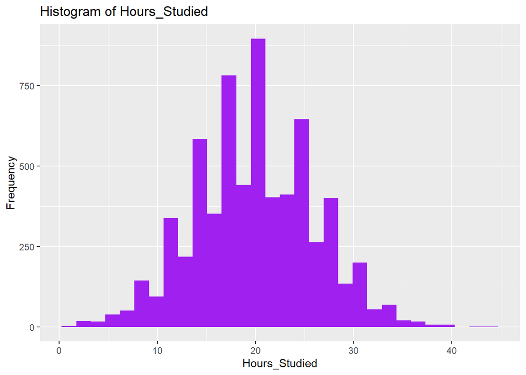

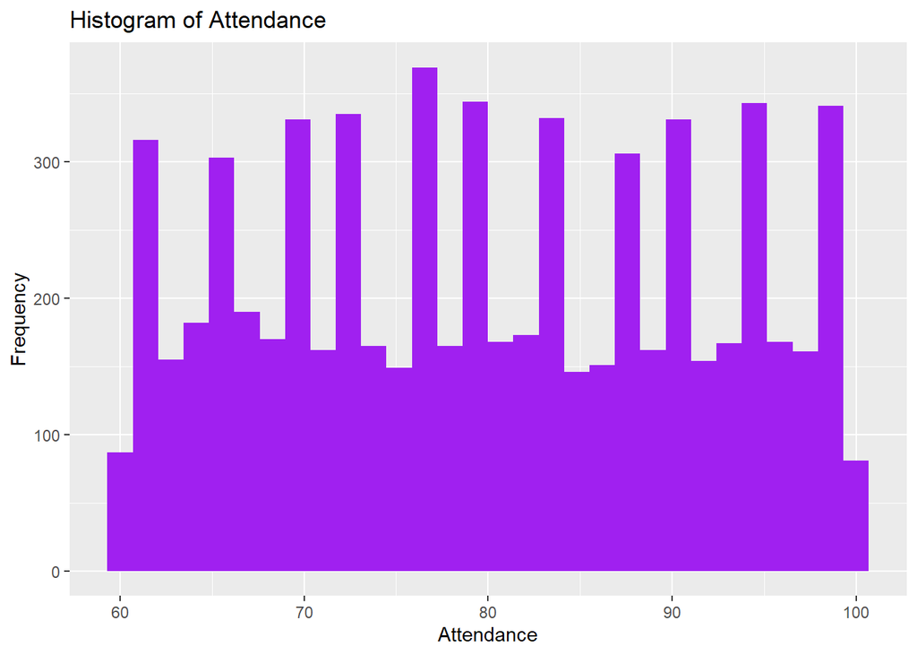

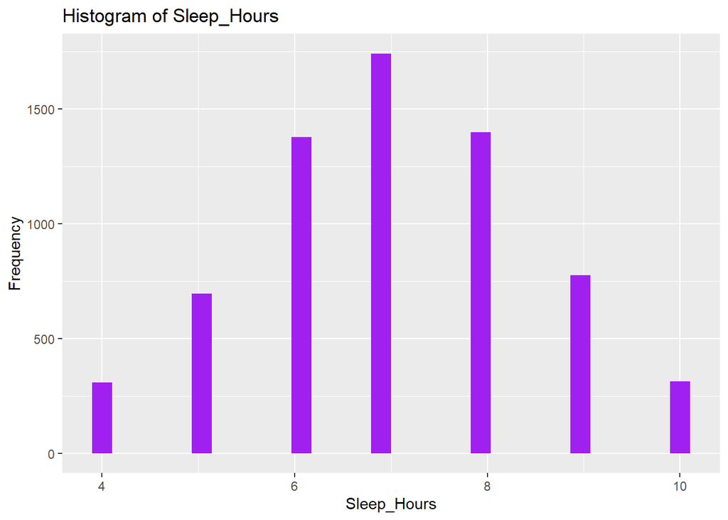

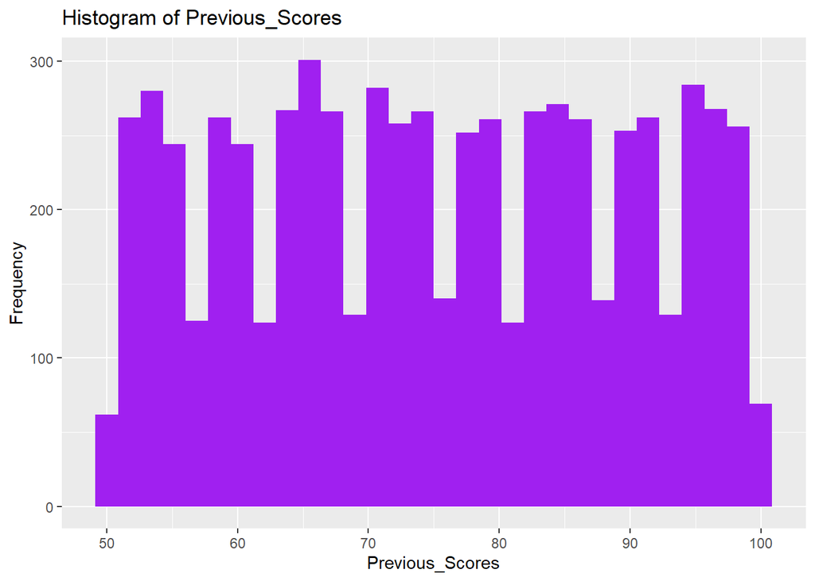

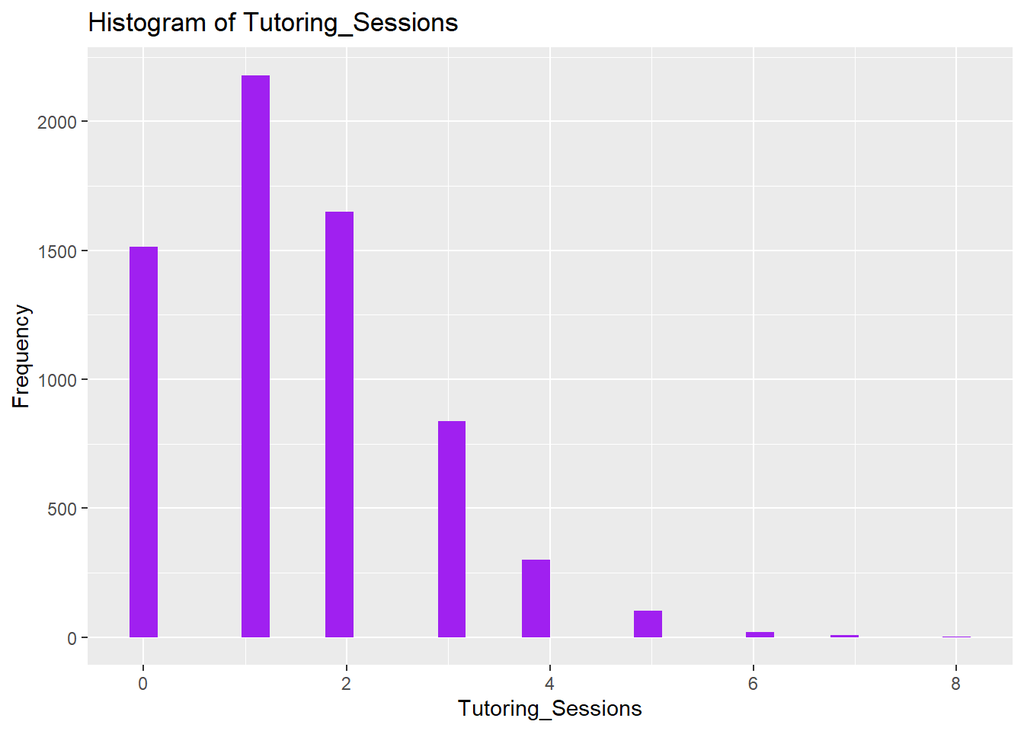

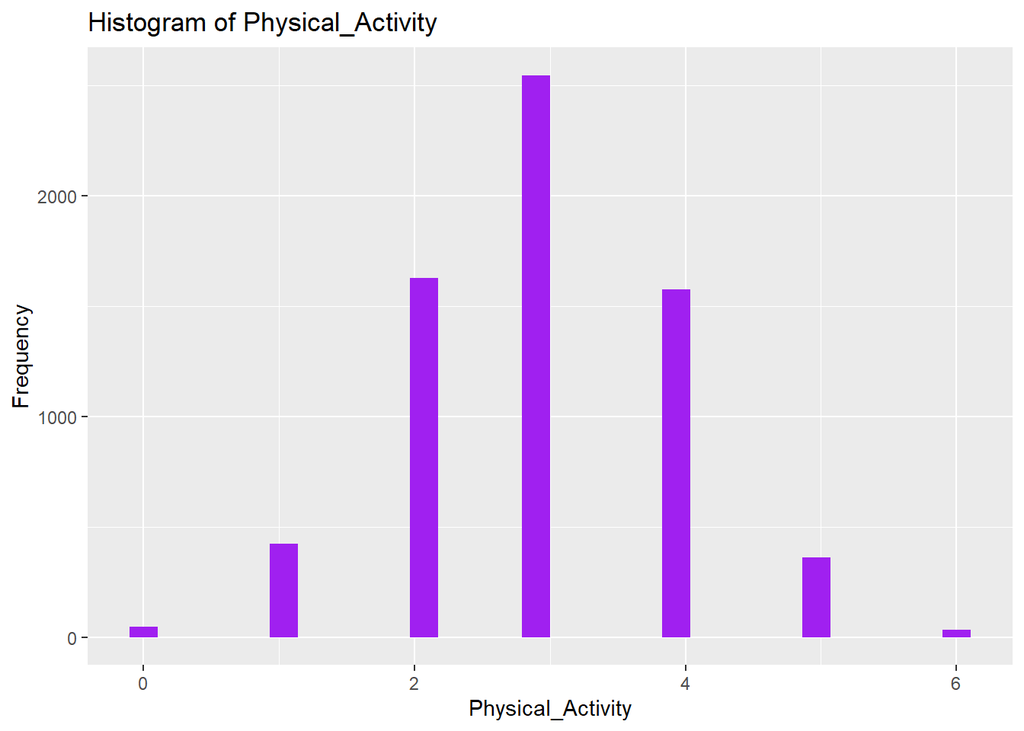

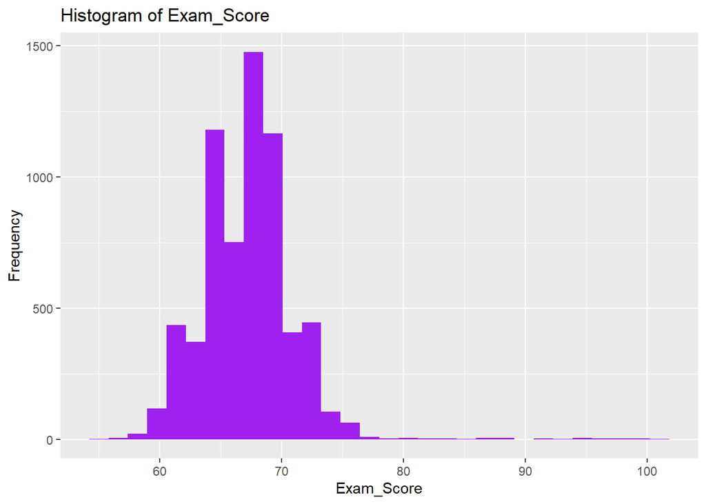

```r
#Plot Histogram of numeric column
numeric_column<-names(data)[sapply(data,is.numeric)]
lapply(numeric_column,function(column){
   ggplot(data,aes_string(x=column))+geom_histogram(fill="PURPLE")+labs(title=paste("Histogram of",column),x=column,y="Frequency")
})
```

#plot bar chart of categorical column

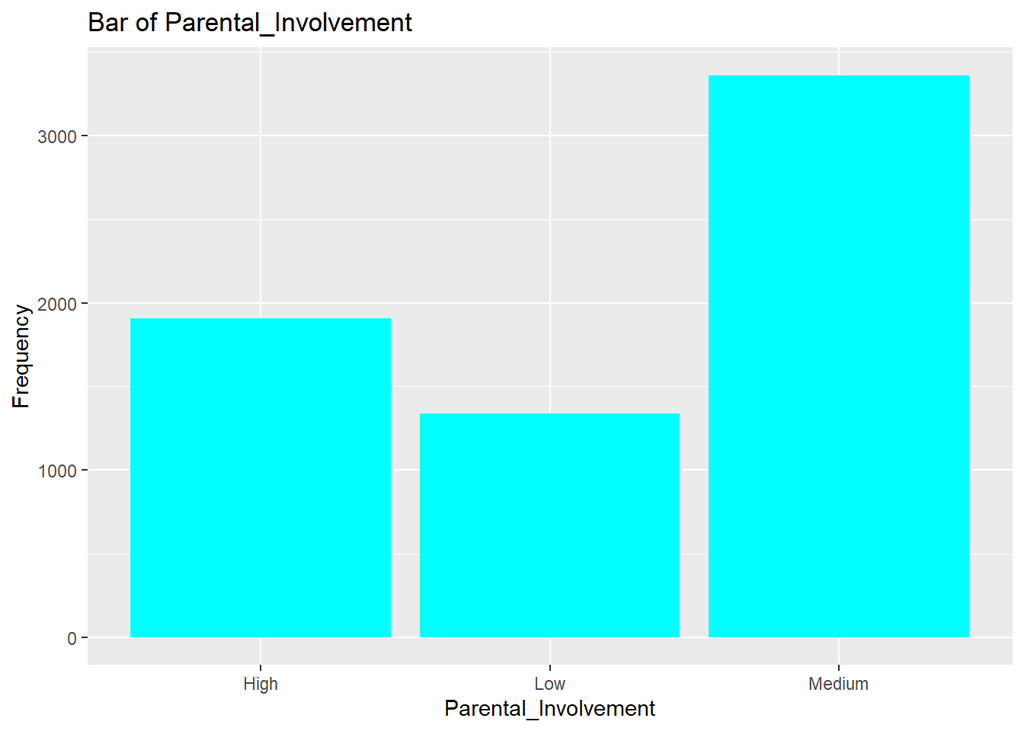

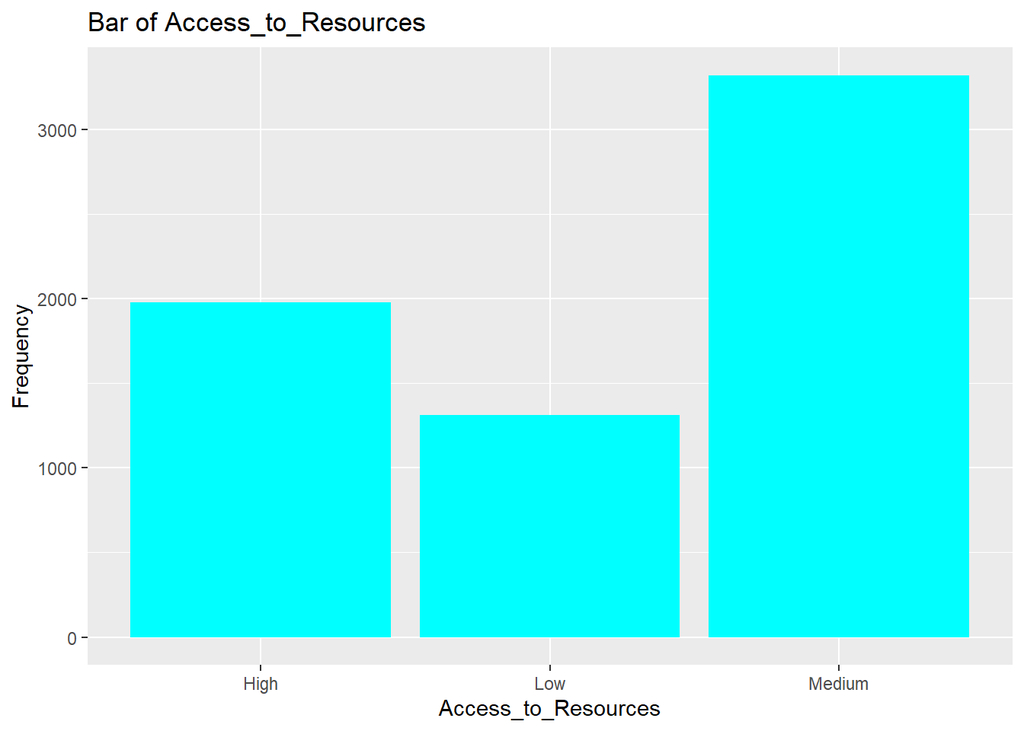

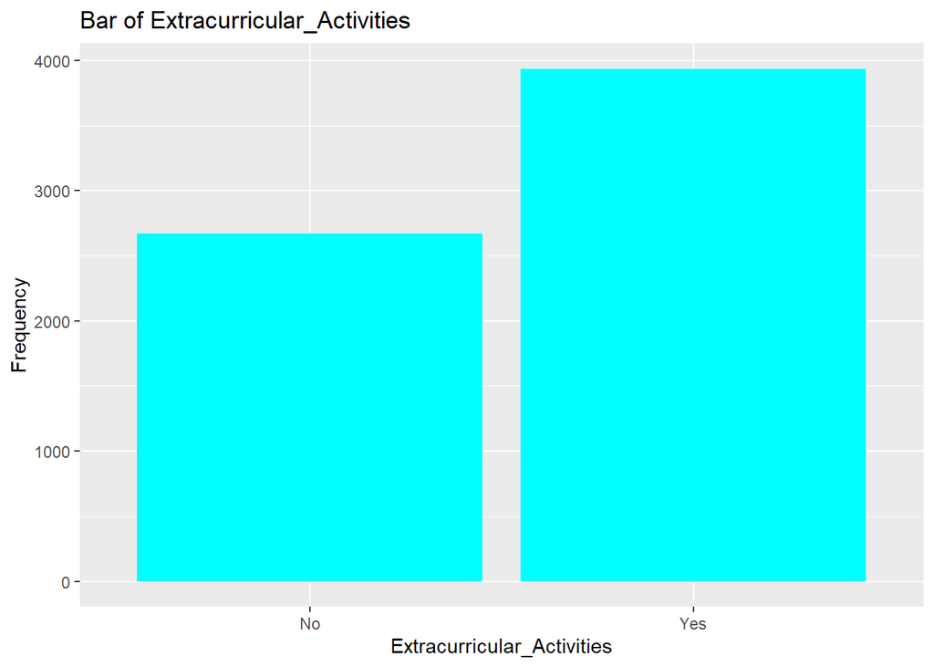

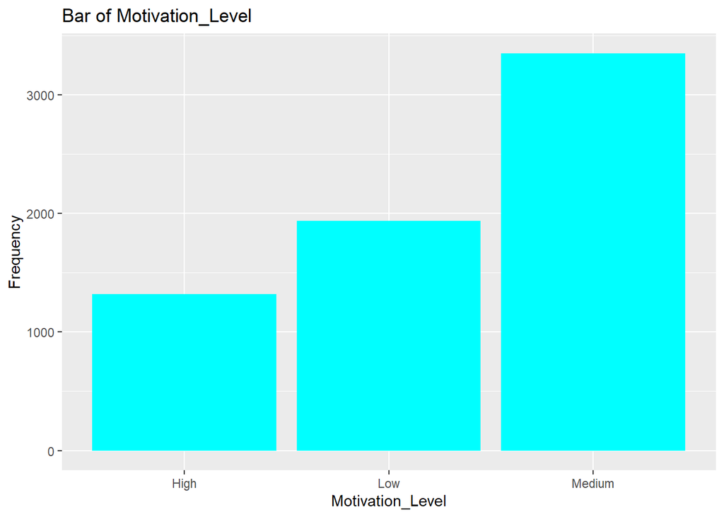

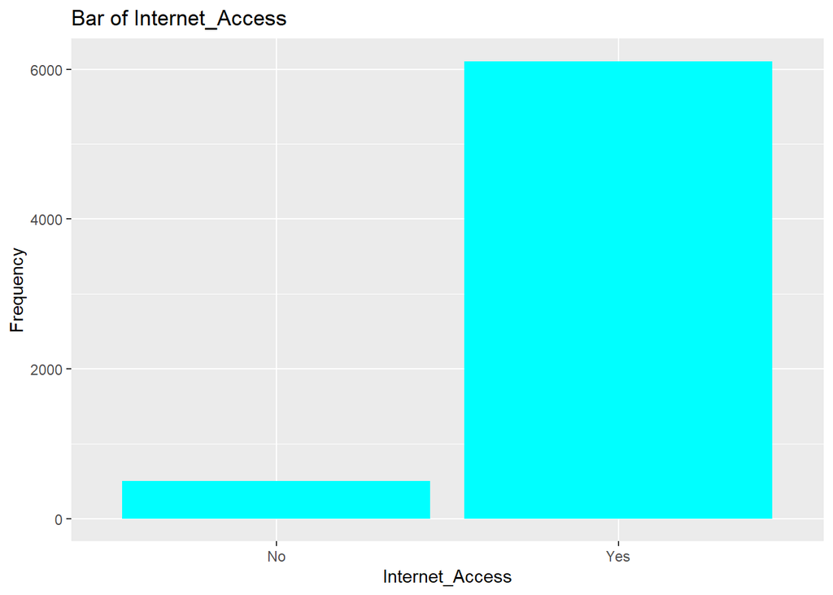

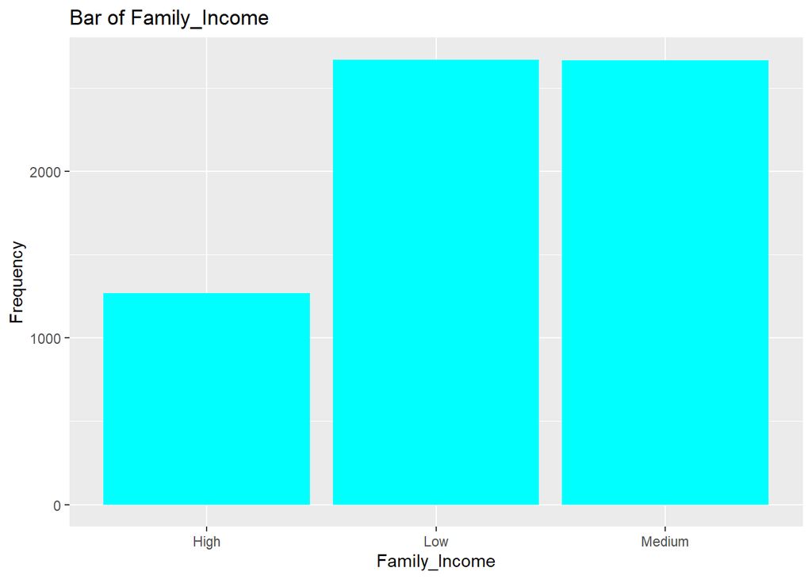

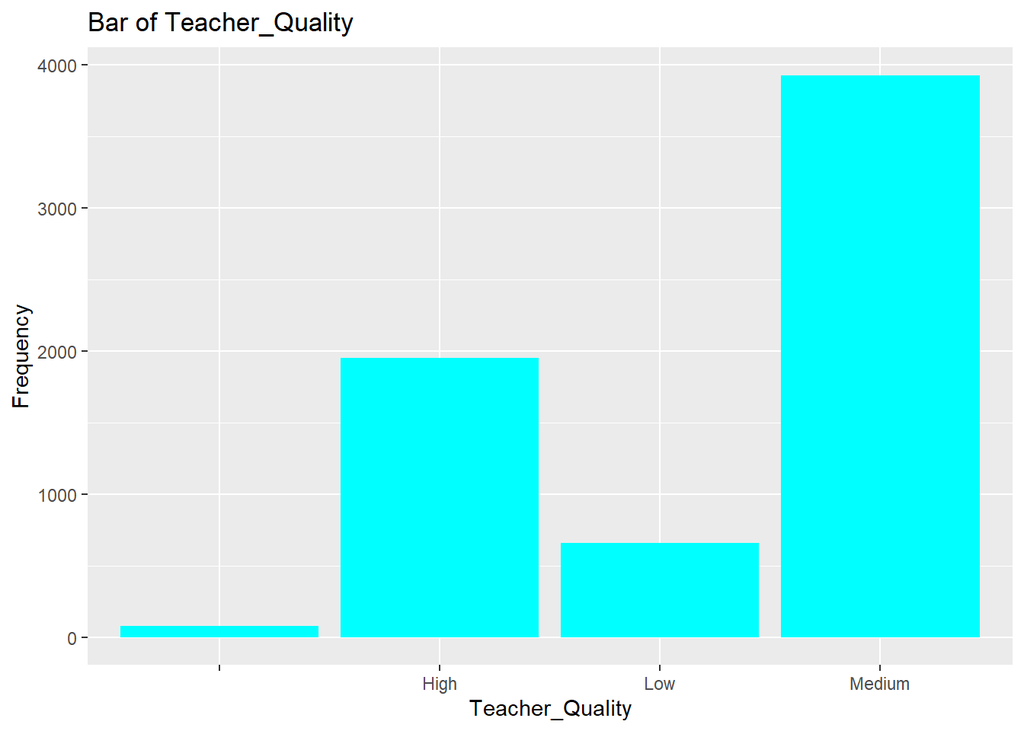

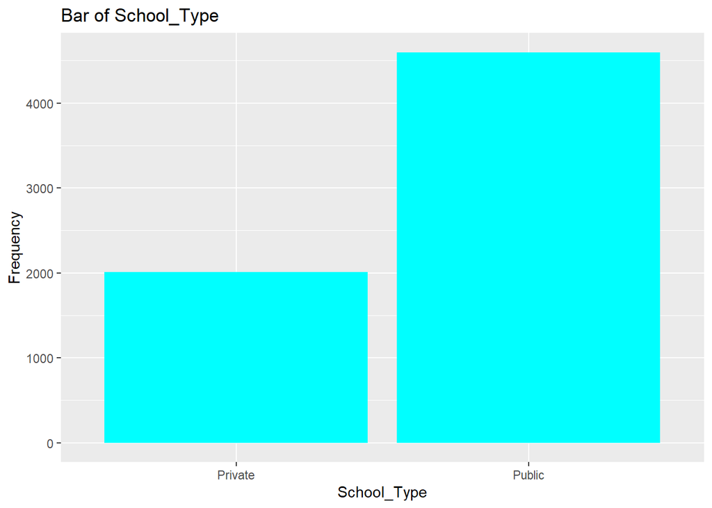

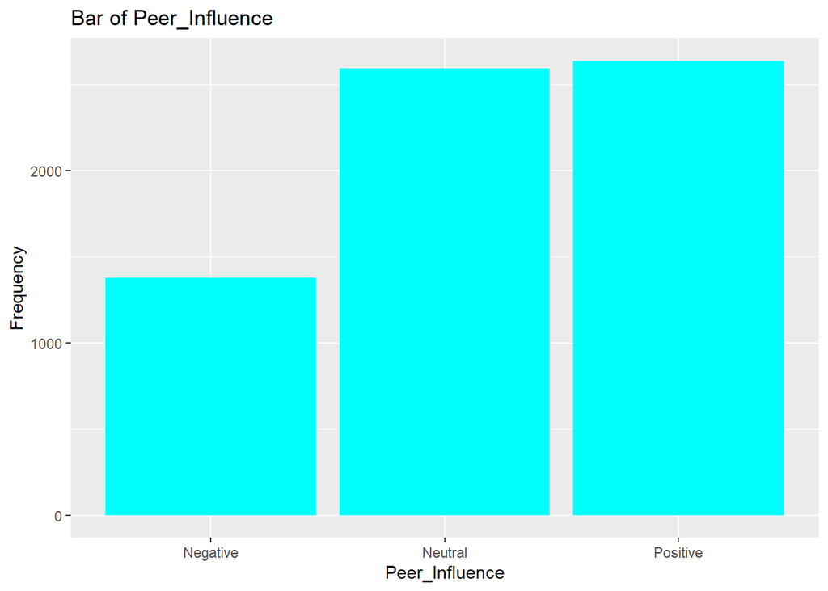

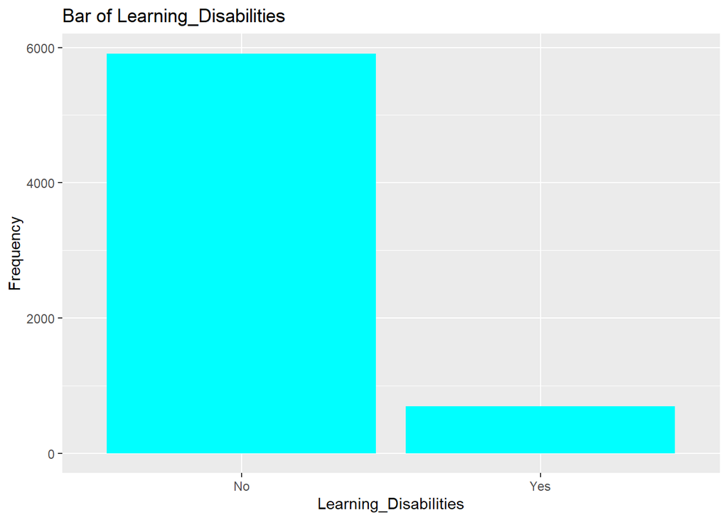

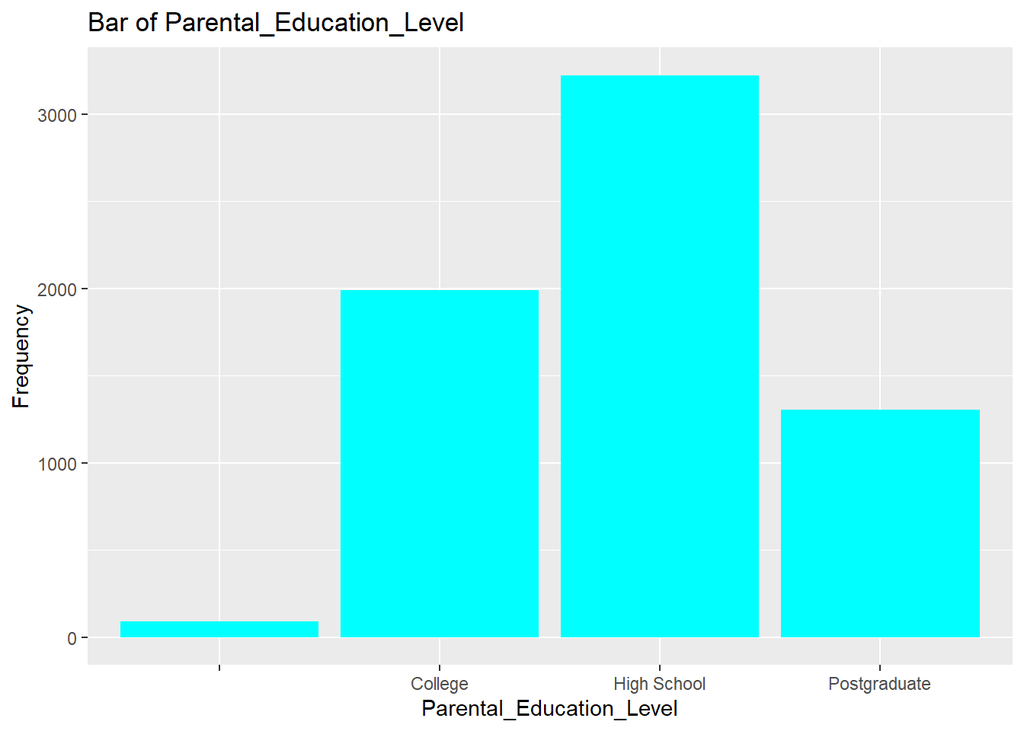

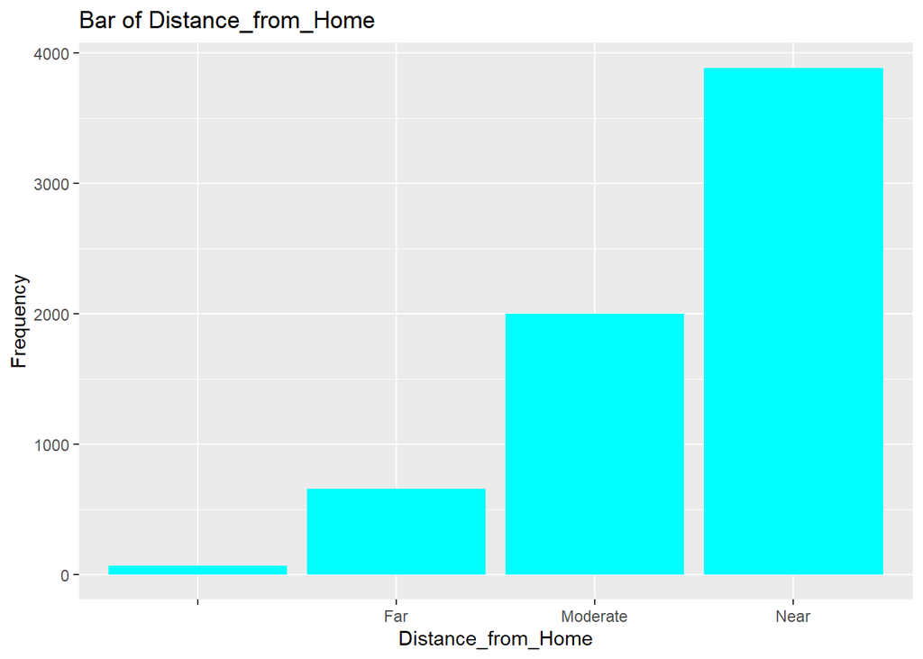

[1 more figures not shown]

```r
categorical_column<-names(data)[sapply(data,is.character)]
lapply(categorical_column,function(column){
  ggplot(data,aes_string(x=column))+geom_bar(fill="CYAN")+labs(title=paste("Bar of",column),x=column,y="Frequency")
})
```

#plot box plot of numerical columns

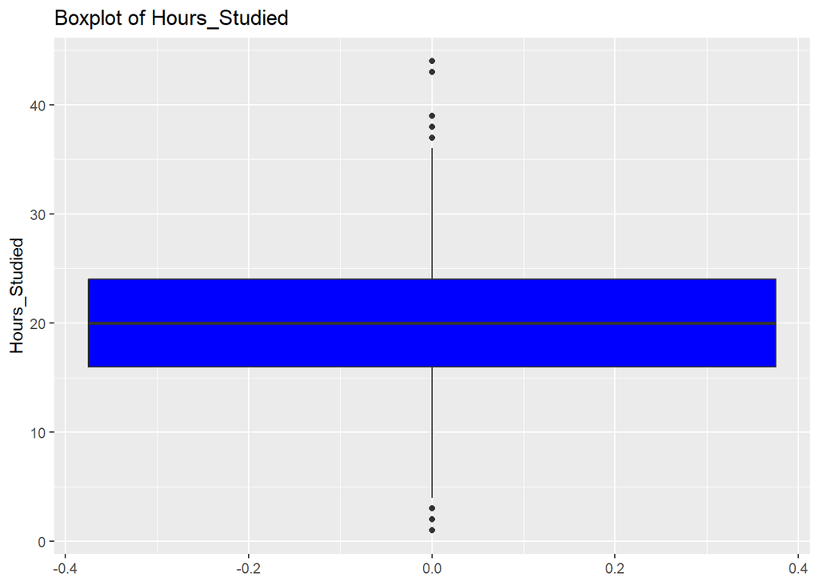

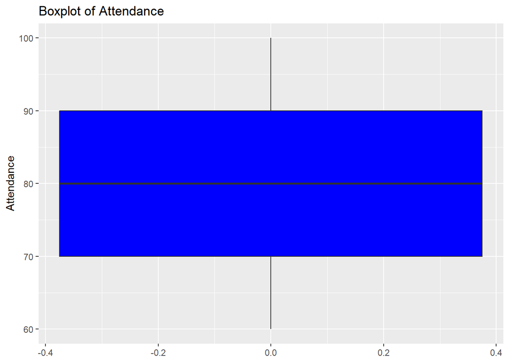

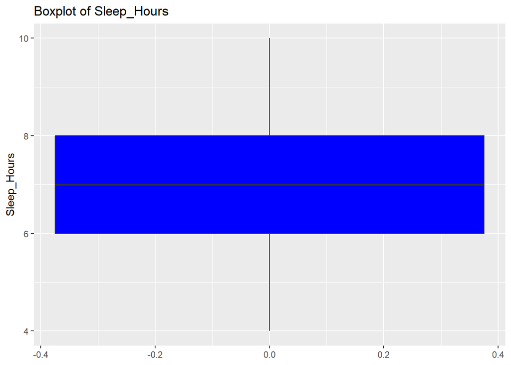

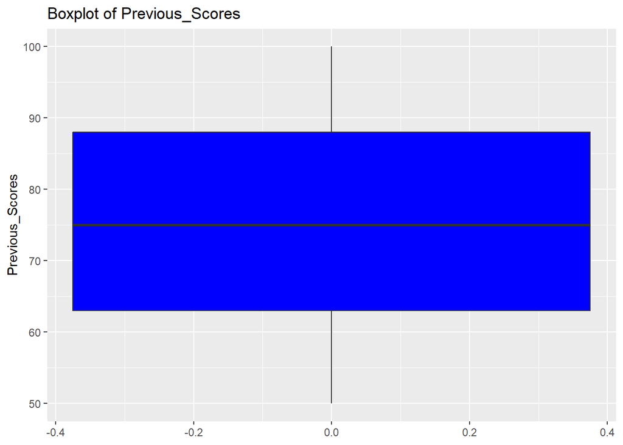

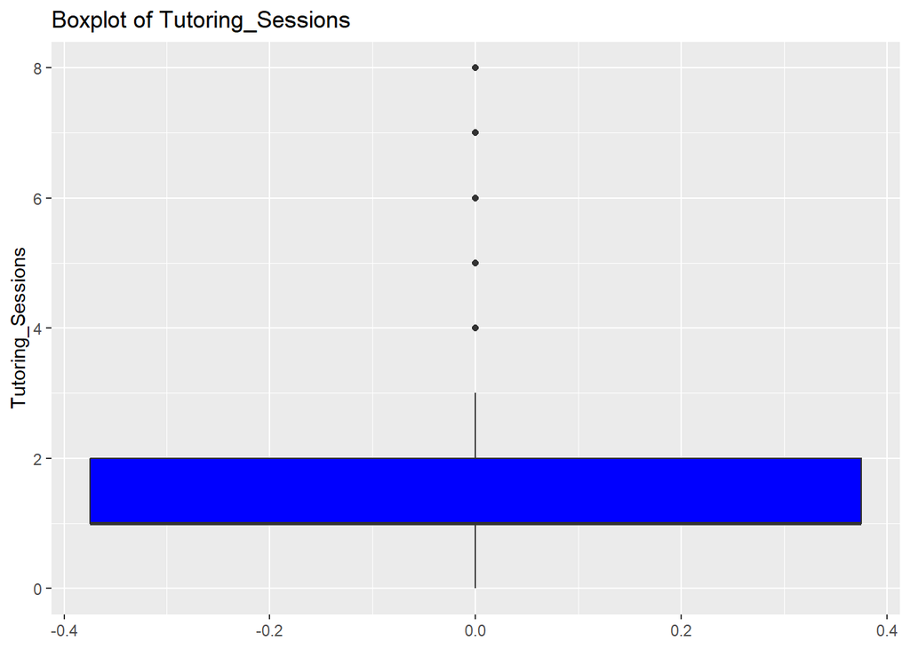

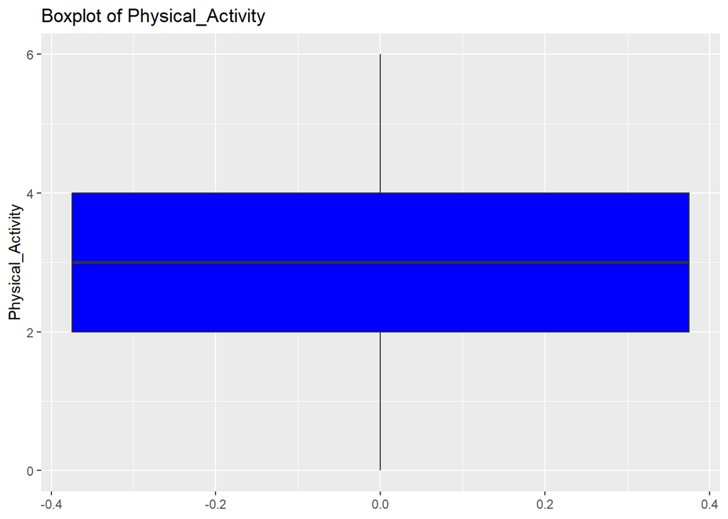

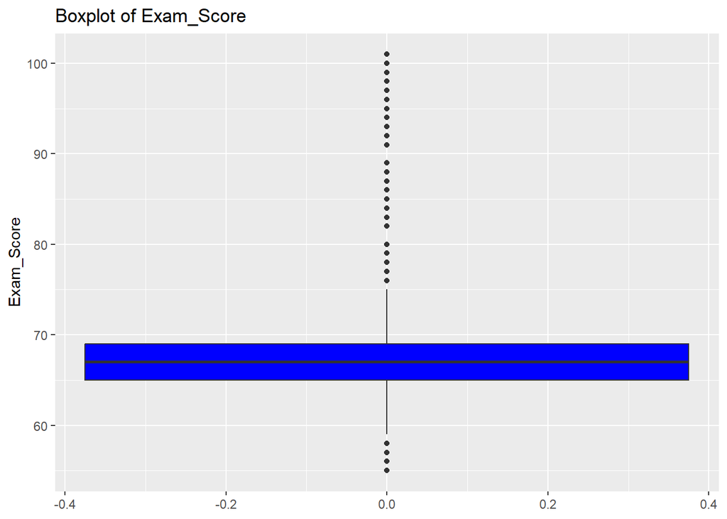

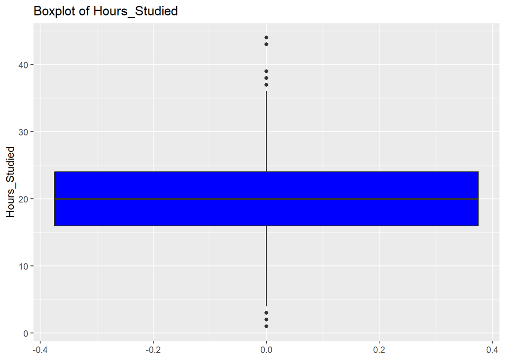

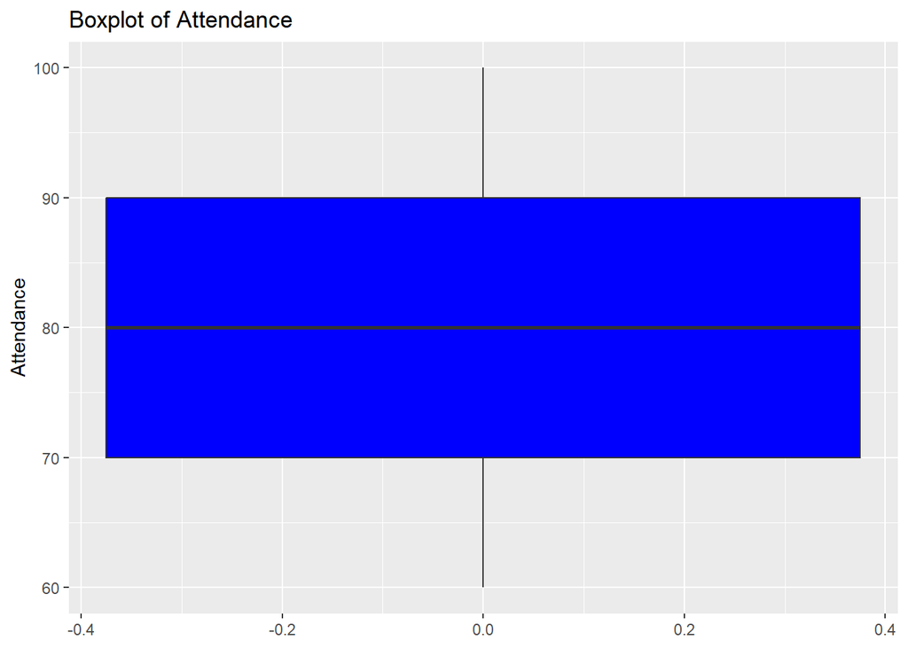

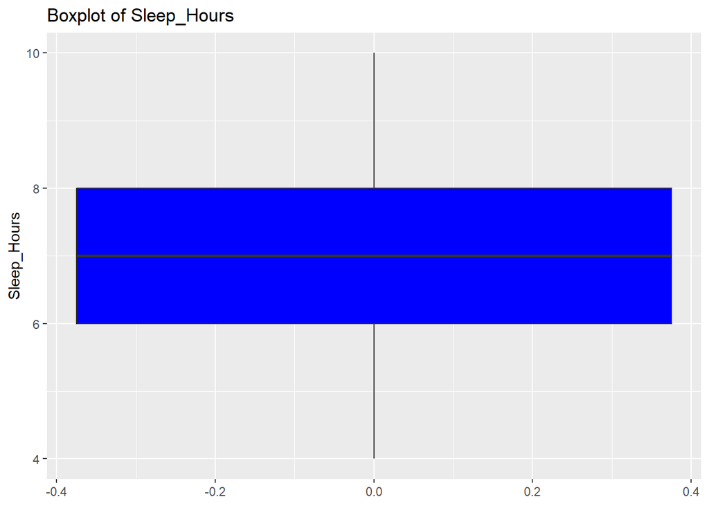

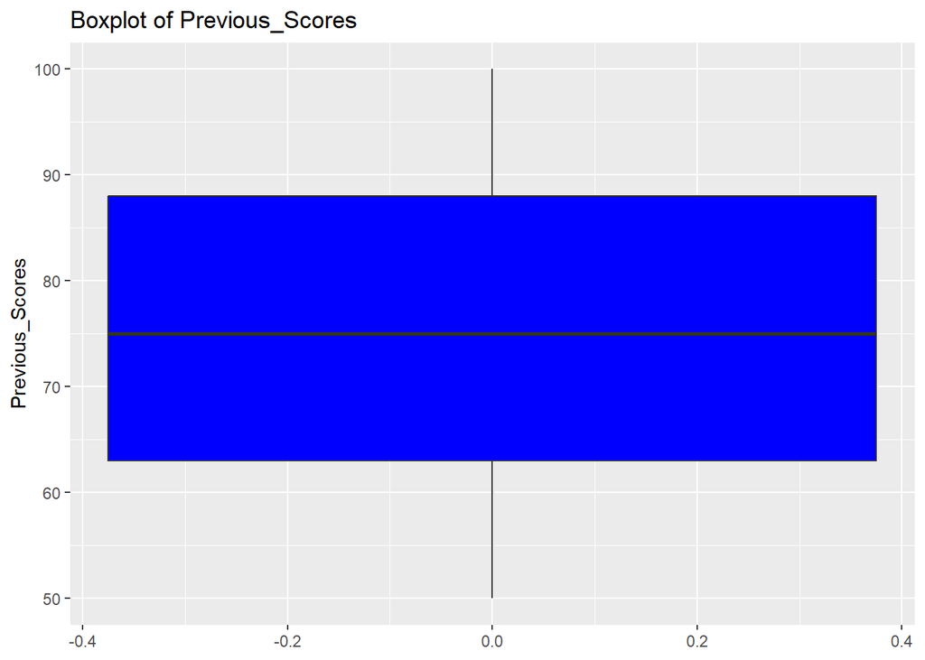

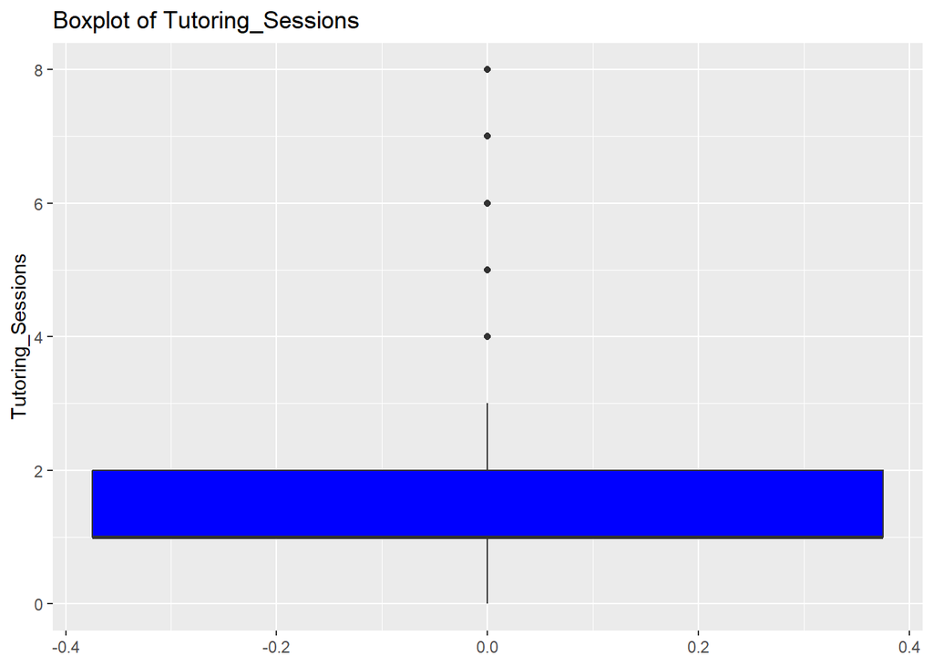

[2 more figures not shown]

```r
numeric_column<-names(data)[sapply(data,is.numeric)]
lapply(numeric_column,function(column){
  p<-ggplot(data,aes_string(y=column))+geom_boxplot(fill="BLUE")+labs(title=paste("Boxplot of",column),y=column)
  print(p)
})
```